# project_bank_churn

# Key meaningful Observation between HasCrCard and Exited

## Some observations from the plot below:

- Nothing significant to report here. But slighly indicates, people with card has exited less compared to people with no card

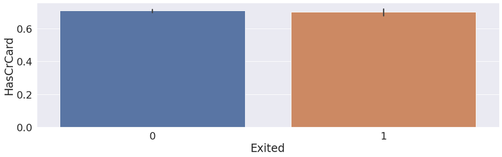

```python
draw_bar_plot(x=data["Exited"],
              y=data["HasCrCard"])
```

# Key meaningful Observation between IsActiveMember and Exited

## Some observations from the plot below:

- A person who is an active member has exited less compared to lesser active members.

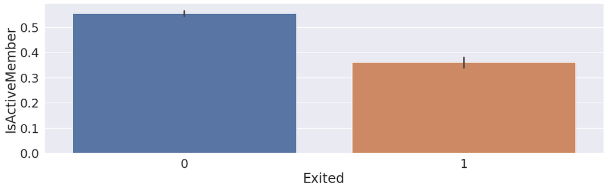

```python
draw_bar_plot(x=data["Exited"],
              y=data["IsActiveMember"])
```

# Key meaningful Observation between salary and Exited

## Some observations from the plot below:

- Nothing significant to report here.

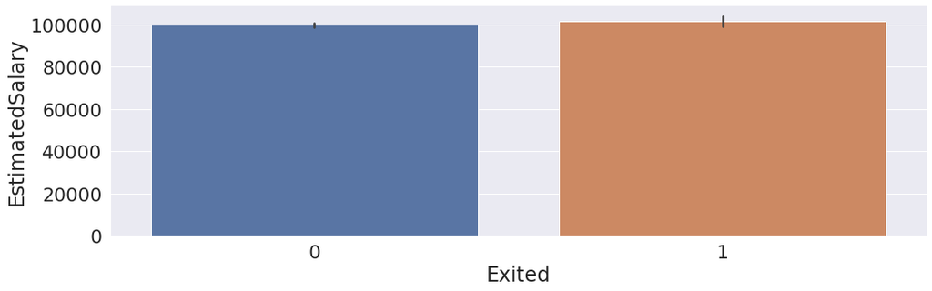

```python
draw_bar_plot(x=data["Exited"],
              y=data["EstimatedSalary"])
```

# Key meaningful Observation between balance and Exited

## Some observations from the plot below:

- Folks with higher balance have exited more compared to lower balance members.

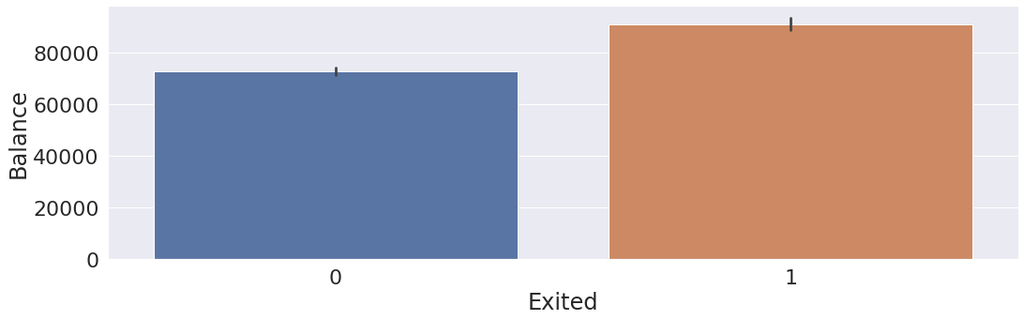

```python
draw_bar_plot(x=data["Exited"],
              y=data["Balance"])
```

# Key meaningful Observation between Gender and Balance

## Some observations from the plot below:

- Nothing significant to report here.

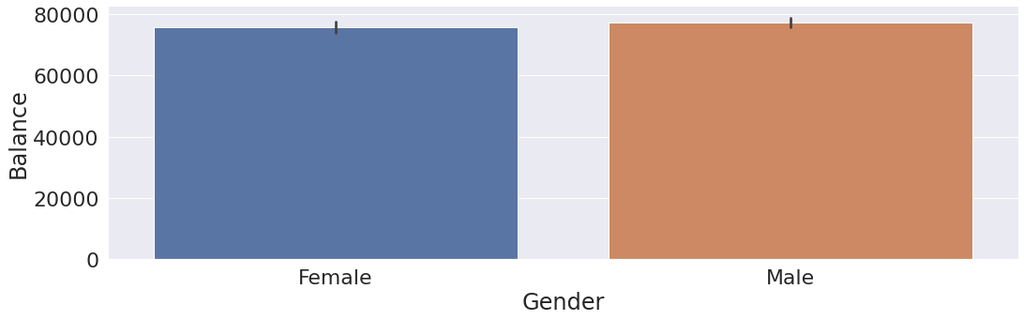

```python
draw_bar_plot(x=data["Gender"],
              y=data["Balance"])
```

# Key meaningful Observation between Gender and CreditScore

## Some observations from the plot below:

- Nothing significant to report here.

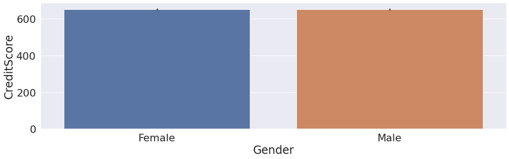

```python
draw_bar_plot(x=data["Gender"],
              y=data["CreditScore"])
```

# Key meaningful observation between Gender and salary

## Some observations from the plot below:

- Nothing significant to report here.

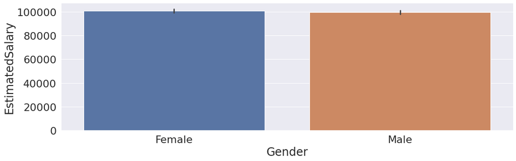

```python
draw_bar_plot(x=data["Gender"],
              y=data["EstimatedSalary"])
```

# Key meaningful Observation between Gender and Balance

## Some observations from the plot below:

- Nothing significant to report here.

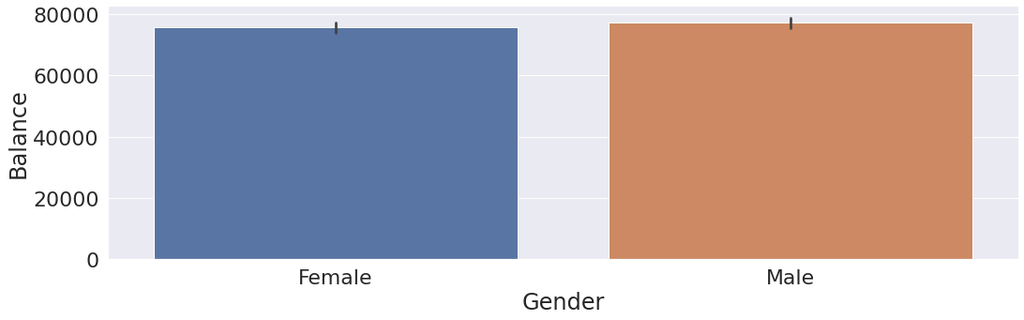

```python
draw_bar_plot(x=data["Gender"],
              y=data["Balance"])
```

# Key meaningful Observation between Balance and number of products

## Some observations from the plot below:

- Members with just 1 product have the most higher balance
- Members with just 2 products have the least balance
- Members with just 4 products have lesser balance compared to members with 1 product.

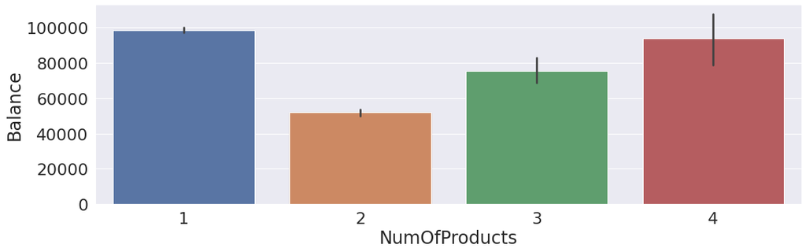

```python
draw_bar_plot(x=data["NumOfProducts"],
              y=data["Balance"])
```

```python
data.head()
```

|  | CreditScore | Geography | Gender | Age | Tenure | Balance | NumOfProducts | HasCrCard | IsActiveMember | EstimatedSalary | Exited |
| --- | --- | --- | --- | --- | --- | --- | --- | --- | --- | --- | --- |
| 0 | 619 | France | Female | 42 | 2 | 0.00 | 1 | 1 | 1 | 101348.88 | 1 |
| 1 | 608 | Spain | Female | 41 | 1 | 83807.86 | 1 | 0 | 1 | 112542.58 | 0 |
| 2 | 502 | France | Female | 42 | 8 | 159660.80 | 3 | 1 | 0 | 113931.57 | 1 |
| 3 | 699 | France | Female | 39 | 1 | 0.00 | 2 | 0 | 0 | 93826.63 | 0 |
| 4 | 850 | Spain | Female | 43 | 2 | 125510.82 | 1 | 1 | 1 | 79084.10 | 0 |

# Data Pre-processing - prepping the categorical features

```python
oneHotCols=["Geography","Gender"]
data_prepped=pd.get_dummies(data, columns=oneHotCols)
data_prepped.head(10)
```

|  | CreditScore | Age | Tenure | Balance | NumOfProducts | HasCrCard | IsActiveMember | EstimatedSalary | Exited | Geography_France | Geography_Germany | Geography_Spain | Gender_Female | Gender_Male |
| --- | --- | --- | --- | --- | --- | --- | --- | --- | --- | --- | --- | --- | --- | --- |
| 0 | 619 | 42 | 2 | 0.00 | 1 | 1 | 1 | 101348.88 | 1 | 1 | 0 | 0 | 1 | 0 |
| 1 | 608 | 41 | 1 | 83807.86 | 1 | 0 | 1 | 112542.58 | 0 | 0 | 0 | 1 | 1 | 0 |
| 2 | 502 | 42 | 8 | 159660.80 | 3 | 1 | 0 | 113931.57 | 1 | 1 | 0 | 0 | 1 | 0 |
| 3 | 699 | 39 | 1 | 0.00 | 2 | 0 | 0 | 93826.63 | 0 | 1 | 0 | 0 | 1 | 0 |
| 4 | 850 | 43 | 2 | 125510.82 | 1 | 1 | 1 | 79084.10 | 0 | 0 | 0 | 1 | 1 | 0 |
| 5 | 645 | 44 | 8 | 113755.78 | 2 | 1 | 0 | 149756.71 | 1 | 0 | 0 | 1 | 0 | 1 |
| 6 | 822 | 50 | 7 | 0.00 | 2 | 1 | 1 | 10062.80 | 0 | 1 | 0 | 0 | 0 | 1 |
| 7 | 376 | 29 | 4 | 115046.74 | 4 | 1 | 0 | 119346.88 | 1 | 0 | 1 | 0 | 1 | 0 |
| 8 | 501 | 44 | 4 | 142051.07 | 2 | 0 | 1 | 74940.50 | 0 | 1 | 0 | 0 | 0 | 1 |
| 9 | 684 | 27 | 2 | 134603.88 | 1 | 1 | 1 | 71725.73 | 0 | 1 | 0 | 0 | 0 | 1 |

# Data Pre-processing - Split the target variable and predictors

```python
X = data_prepped.drop(['Exited'],axis=1)
Y = data_prepped[['Exited']]
```

# Data Pre-processing - Split the data into train and test

```python
X_train, X_test, y_train, y_test = train_test_split(X,Y, test_size = 0.2, random_state = 0)
```

# Data Pre-processing - Rescale the data

```python
sc=StandardScaler()
X_train = sc.fit_transform(X_train)
X_test = sc.transform(X_test)
```

# Model building - Initialize the parameters first

```python
# Get the number of input features for the input layer
_,num_input_features=np.shape(X_train)

# Get the number of output layers
_,num_output_layers=np.shape(y_train)

# Get the type of activation function for dense layers
dense_activation_type="relu"

# Get the type of activation function for dense layers
output_activation_type="sigmoid"

# Specify the loss function type
loss_function_type="binary_crossentropy"

# Specify the metric used
metric_type="accuracy"

# Specify the type of optimizer
optimizer_type="adam"
```

# Model building

## Model - 1

- Lets start with mininmal layers and epoch

```python
model = keras.Sequential([
    keras.layers.Dense(6,
                       input_shape=(num_input_features,),
                       activation=dense_activation_type),
    keras.layers.Dense(6, activation=dense_activation_type),
    keras.layers.Dense(num_output_layers,activation=output_activation_type)
])
model.compile(optimizer=optimizer_type,
              loss=loss_function_type,
              metrics=[metric_type])
history=model.fit(X_train, y_train, epochs=20,validation_split=0.2)
```

# Training vs validation plot (shown below) for model-1 above

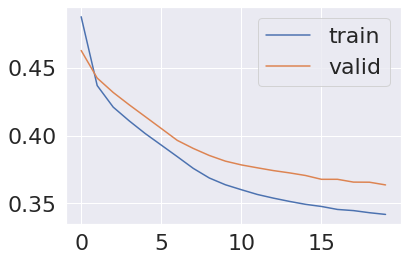

```python
plot_train_vs_val(history)
```

# Recall score with model-1

```python
threshold=0.5
y_pred = model.predict(X_test)
for i in range(len(y_test)):
    if y_pred[i]>=0.5:
        y_pred[i]=1
    else:
        y_pred[i]=0
recall,_,_ = estimate_performance_metric(y_test,y_pred)
print(f"Recall_score:{recall}")
```

```
Recall_score:0.49135802469135803
```

# Model Performance Improvement - Which metric is right for model performance evaluation and why?

Lets establish our labels first:

- True Positive: A person predicted as leaving the bank, did leave the bank.
- True Negative: A person predicated as not leaving, did not leave the bank.
- False Positive: A person predicted as leaving the bank, did not leave the bank.
- False Negative: A person predicted as not leaving the bank, has left the bank.

So of all these, **False Negative** is the most harmful, since the bank looses a customer. So we should increase our **recall** to keep the **False Negative** to the minimum.

# Model Performance Improvement

Based on the plots above under "Training vs validation plot (shown below) for model-1 above", there is **clear signs of overfitting**, as the train loss is lesser compared to validation loss.

## Model performance

### Thoughts on improving the model

- we could increase the number of dense layers
- Start with better initialization (than just default)
- Increase the number of epochs
- Add dropout and see if it helps with over fitting.
- Add batch normalization and see if it helps with over fitting.

# Model Improvement-Model 2

- We will introduce **"he_normal"** intialization and see if it helps.

```python
model = keras.Sequential([
    keras.layers.Dense(6,
                       input_shape=(num_input_features,),
                       kernel_initializer='he_normal',
                       activation=dense_activation_type),
    keras.layers.Dense(6, activation=dense_activation_type,kernel_initializer='he_normal'),
    keras.layers.Dense(num_output_layers,activation=output_activation_type,kernel_initializer='he_normal')
])
model.compile(optimizer=optimizer_type,
              loss=loss_function_type,
              metrics=[metric_type])
history=model.fit(X_train, y_train, epochs=20,validation_split=0.2)
```

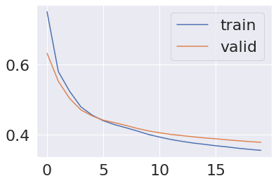

```python
plot_train_vs_val(history)
```

# Comment on Model 2 performance

# Model Improvement - Model *3*

- Lets just increase the epoch to 200 on Model 2 and see if it helps.

```python
model = keras.Sequential([
    keras.layers.Dense(6,
                       input_shape=(num_input_features,),
                       kernel_initializer='he_normal',
                       activation=dense_activation_type),
    keras.layers.Dense(6, activation=dense_activation_type,kernel_initializer='he_normal'),
    keras.layers.Dense(num_output_layers,activation=output_activation_type,kernel_initializer='he_normal')
])
model.compile(optimizer=optimizer_type,
              loss=loss_function_type,
              metrics=[metric_type])
history=model.fit(X_train, y_train, epochs=200,validation_split=0.2)
```

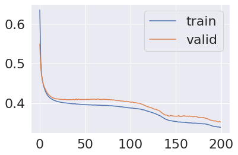

```python
plot_train_vs_val(history)
```